# Analysis of variance

## Packages

```r
library(tidyverse)
library(smmr)
library(PMCMRplus)
```

## Jumping rats

- Link between exercise and healthy bones (many studies).
- Exercise stresses bones and causes them to get stronger.
- Study (Purdue): effect of jumping on bone density of growing rats.
- 30 rats, randomly assigned to 1 of 3 treatments:
  - No jumping (control)
  - Low-jump treatment (30 cm)
  - High-jump treatment (60 cm)
- 8 weeks, 10 jumps/day, 5 days/week.
- Bone density of rats (mg/cm$^3$) measured at end.

## Jumping rats 2/2

- See whether larger amount of exercise (jumping) went with higher bone density.
- Random assignment: rats in each group similar in all important ways.
- So entitled to draw conclusions about cause and effect.

## Reading the data

Values separated by spaces:

```r
my_url <- "http://ritsokiguess.site/datafiles/jumping.txt"
rats <- read_delim(my_url," ")
```

## The data

```r
# rats %>% slice_sample(n=10)
rats
```

| group | density |
| --- | --- |
| Control | 611 |
| Control | 621 |
| Control | 614 |
| Control | 593 |
| Control | 593 |
| Control | 653 |
| Control | 600 |
| Control | 554 |
| Control | 603 |
| Control | 569 |

[output cut: 20 more lines]

## Boxplots

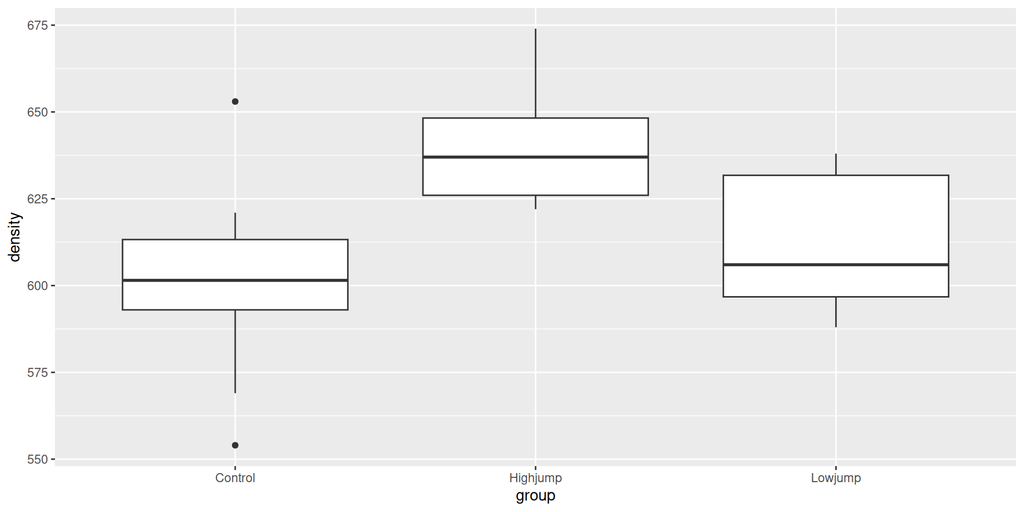

```r
ggplot(rats, aes(y=density, x=group)) + geom_boxplot()
```

## Or, arranging groups in data (logical) order

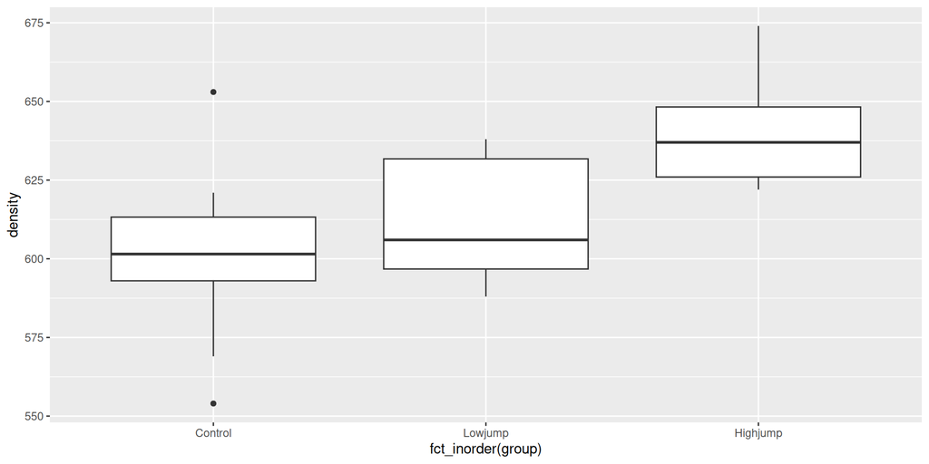

```r
ggplot(rats, aes(y=density, x=fct_inorder(group))) +
  geom_boxplot()
```

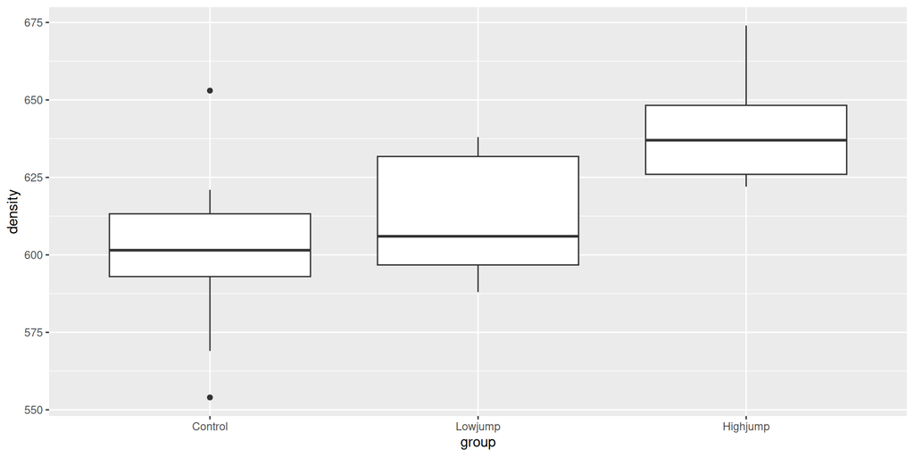

```r
rats %>% mutate(group = fct_inorder(group)) -> rats
ggplot(rats, aes(y=density, x=group)) +
  geom_boxplot()
```

## Analysis of Variance

- Comparing > 2 groups of independent observations (each rat only does one amount of jumping).
- Standard procedure: analysis of variance (ANOVA).
- Null hypothesis: all groups have same mean.
- Alternative: “not all means the same”, at least one is different from others.

## Testing: ANOVA in R

```r
rats.aov <- aov(density ~ group, data=rats)
summary(rats.aov)
```

```
            Df Sum Sq Mean Sq F value Pr(>F)
group        2   7434    3717   7.978 0.0019 **
Residuals   27  12579     466
---
Signif. codes:  0 '***' 0.001 '**' 0.01 '*' 0.05 '.' 0.1 ' ' 1
```

- Usual ANOVA table, small P-value: significant result.
- Conclude that the mean bone densities are not all equal.
- Reject null, but not very useful finding.

## Which groups are different from which?

- ANOVA really only answers half our questions: it says “there are differences”, but doesn’t tell us which groups different.
- One possibility (not the best): compare all possible pairs of groups, via two-sample t.
- First pick out each group:

```r
rats %>% filter(group=="Control") -> controls
rats %>% filter(group=="Lowjump") -> lows
rats %>% filter(group=="Highjump") -> highs
```

## Control vs. low

```r
t.test(controls$density, lows$density)
```

```
    Welch Two Sample t-test

data:  controls$density and lows$density
t = -1.0761, df = 16.191, p-value = 0.2977
alternative hypothesis: true difference in means is not equal to 0
95 percent confidence interval:
 -33.83725  11.03725
sample estimates:
mean of x mean of y
    601.1     612.5
```

No sig. difference here.

## Control vs. high

```r
t.test(controls$density, highs$density)
```

```
    Welch Two Sample t-test

data:  controls$density and highs$density
t = -3.7155, df = 14.831, p-value = 0.002109
alternative hypothesis: true difference in means is not equal to 0
95 percent confidence interval:
 -59.19139 -16.00861
sample estimates:
mean of x mean of y
    601.1     638.7
```

These are different.

## Low vs. high

```r
t.test(lows$density, highs$density)
```

```
    Welch Two Sample t-test

data:  lows$density and highs$density
t = -3.2523, df = 17.597, p-value = 0.004525
alternative hypothesis: true difference in means is not equal to 0
95 percent confidence interval:
 -43.15242  -9.24758
sample estimates:
mean of x mean of y
    612.5     638.7
```

These are different too.

## But…

- We just did 3 tests instead of 1.
- So we have given ourselves 3 chances to reject $H_0:$ all means equal, instead of 1.
- Thus $\alpha$ for this combined test is not 0.05.

## John W. Tukey

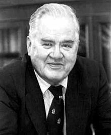

- American statistician, 1915–2000
- Big fan of exploratory data analysis
- Popularized boxplot
- Invented “honestly significant differences”
- Invented jackknife estimation
- Coined computing term “bit”
- Co-inventor of Fast Fourier Transform

## Honestly Significant Differences

- Compare several groups with one test, telling you which groups differ from which.
- Idea: if all population means equal, find distribution of highest sample mean minus lowest sample mean.
- Any means unusually different compared to that declared significantly different.

## Tukey on rat data

```r
rats.aov <- aov(density~group, data = rats)
TukeyHSD(rats.aov)
```

```
  Tukey multiple comparisons of means
    95% family-wise confidence level

Fit: aov(formula = density ~ group, data = rats)

$group
                 diff        lwr      upr     p adj
Lowjump-Control  11.4 -12.533957 35.33396 0.4744032
Highjump-Control 37.6  13.666043 61.53396 0.0016388
Highjump-Lowjump 26.2   2.266043 50.13396 0.0297843
```

- Again conclude that bone density for highjump group significantly higher than for other two groups.

## Why Tukey’s procedure better than all t-tests

Look at P-values for the two tests:

```
Comparison        Tukey    t-tests
----------------------------------
Highjump-Control 0.0016     0.0021
Lowjump-Control  0.4744     0.2977
Lowjump-Highjump 0.0298     0.0045
```

- Tukey P-values (mostly) higher.
- Proper adjustment for doing three t-tests at once, not just one in isolation.

## Checking assumptions

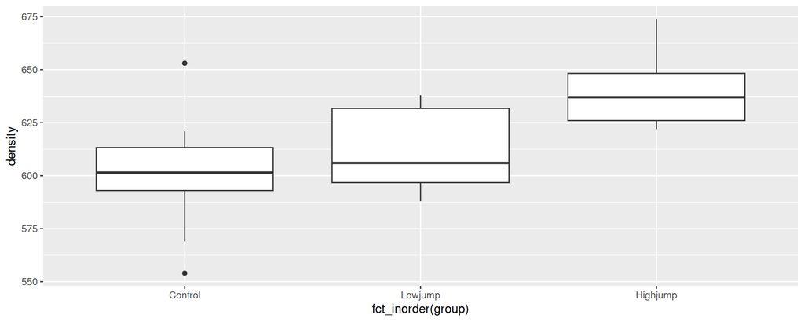

```r
ggplot(rats,aes(y = density, x = fct_inorder(group)))+
  geom_boxplot()
```

Assumptions:

- Normally distributed data within each group
- with equal group SDs.

## Normal quantile plots by group

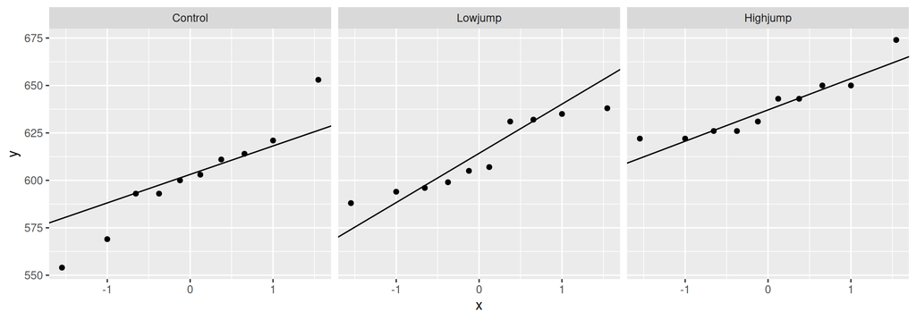

```r
ggplot(rats, aes(sample = density)) + stat_qq() +
  stat_qq_line() + facet_wrap( ~ group)
```

## Mood’s median for multiple groups

- Find median of all bone densities, regardless of group
- Count up how many observations in each group above or below overall median
- Test association between group and above/below
- Mood’s `median_test` (over).

## Mood’s median test here

```r
median_test(rats, density, group)
```

```
$grand_median
[1] 621.5

$table
          above
group      above below
  Control      1     9
  Lowjump      4     6
  Highjump    10     0

$test
       what        value
1 statistic 1.680000e+01
2        df 2.000000e+00
3   P-value 2.248673e-04
```

## Comments

- No doubt that medians differ between groups (not all same).
- This test is equivalent of $F$-test, not of Tukey.
- To determine which groups differ from which, can compare all possible pairs of groups via (2-sample) Mood’s median tests, then adjust P-values by multiplying by number of 2-sample Mood tests done (Bonferroni):

```r
pairwise_median_test(rats, density, group)
```

[output not shown]

- Now, lowjump-highjump difference no longer significant.

## Welch ANOVA

- For these data, Mood’s median test probably best because we doubt both normality and equal spreads.
- When normality OK but spreads differ, Welch ANOVA way to go.
- Welch ANOVA done by `oneway.test` as shown (for illustration):

```r
oneway.test(density~group, data=rats)
```

```
    One-way analysis of means (not assuming equal variances)

data:  density and group
F = 8.8164, num df = 2.000, denom df = 17.405, p-value = 0.002268
```

- P-value very similar, as expected.
- Appropriate Tukey-equivalent here called Games-Howell.

## Games-Howell

- Lives in package `PMCMRplus`. Install first.

```r
gamesHowellTest(density ~ group, data = rats)
```

```
         Control Lowjump
Lowjump  0.5417  -
Highjump 0.0056  0.0120
```

```r
# gamesHowellTest(density ~ factor(group), data = rats)
```

The line below appears to be no longer true:

Careful: explanatory must be `factor` (so commented-out line does not work).

## Deciding which test to do

For two or more samples:

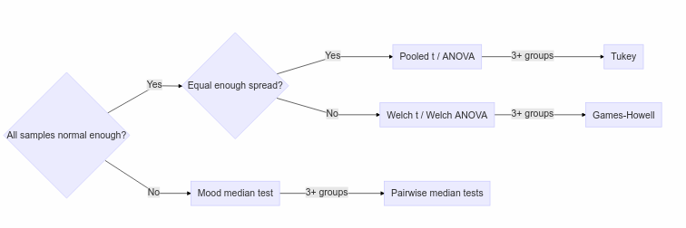